# Final Project

Noah Tamminga

Spring 2022

```r
#install.packages('sf')
#install.packages('ggspatial')
#install.packages('robotstxt')
#install.packages('tigris')
#install.packages('FinCal')


library(tidyverse)
library(ggplot2)
library(sf)
library(ggspatial)
library(rvest)
library(robotstxt)
library(tigris)
library(FinCal)
```

## Project Introduction

For my project, I will focus on exploratory data analysis on data related to the housing market. Because my current organization is partially tied to the overall housing market, it might help to get an understanding of historical price changes, transactions, in-demand geographical areas, and other factors. The housing market is a broad industry to analyze as it can include factors such as prices, price changes, in-demand locations, inflation, interest rates, wages, and a multitude of other factors. The goal of this analysis will be to first understand price levels and price changes across the United States. Following this, additional analyses can be added and new datasets joined to further the analysis in new directions based on interests or discoveries in the wrangling process.

Data for this project will come from [Zillow](https://www.zillow.com/research/data/) which includes a large variety of historical data based on different housing features, adjustments, and other information. Additionally, *if possible* and *reasonable*, extending this analysis by working with [Zillow’s API](https://www.zillow.com/howto/api/APIOverview.htm) might be a helpful tool to access data in another format besides their collection of historical csv files. The datasets from Zillow include multiple areas of interest including home value, forecasts, home inventory, home transactions, and price changes. All these different tables are primarily in wide-format and can be downloaded based on a variety of different combinations of calculation adjustments and geographical specifications.

**Goal**: For this project, the primary goal will be to understand how housing prices have changed proportionally in different states in the United States. Because different costs of living and overall varying asset values must be adjusted for, the analysis will focus on percentage changes in prices rather than nominal values. First, we will gain an understanding of the current nationwide picture of percentage changes in home prices based on each state. With this understanding, we can explore different aspects such as housing demand through housing inventory changes or population changes. Additionally, we can explore housing budget changes that reflect current housing payments as a proportion of income based on current mortgage interest rates. Data for housing inventory comes from [Zillow](https://www.zillow.com/research/data/), data for wages is scraped from the [BLS](https://www.bls.gov/charts/county-employment-and-wages/percent-change-aww-by-state.htm/), and data for interest rates comes from [FRED](https://fred.stlouisfed.org/series/MORTGAGE30US).

## Data Collection

For this project, I will primarily be utilizing historical housing data from Zillow. To aid in reproducibility, the dataset used below can be found on Zillow’s data archive [Zillow](https://www.zillow.com/research/data/). The specific dataset in use can be obtained by going to the *Home Values* section of the webpage and selecting the seasonally adjusted and zipcode parameters for the required inputs to download the csv file. Once downloaded, the correct csv file should have the equivalent name as the dataset read in below. However, as additional months are added to Zillow’s archives this csv file will grow to include more recent data. The dataset I will be using includes home prices based on zipcodes up until March 31, 2022.

Additionally, below in the countrywide analysis section, we utilize geometric shape data to create an accurate visualization of the continental United States. This dataset can be found here: [National Weather Service](https://www.weather.gov/gis/USStates).

```r
housing_data <- read_csv("data/Zip_zhvi_uc_sfrcondo_tier_0.33_0.67_sm_sa_month.csv")
housing_data
```

```
## # A tibble: 27,317 x 276
##    RegionID SizeRank RegionName RegionType StateName State City     Metro
##       <dbl>    <dbl> <chr>      <chr>      <chr>     <chr> <chr>    <chr>
##  1    61639        0 10025      Zip        NY        NY    New York New York-Ne~
##  2    84654        1 60657      Zip        IL        IL    Chicago  Chicago-Nap~
##  3    61637        2 10023      Zip        NY        NY    New York New York-Ne~
##  4    91982        3 77494      Zip        TX        TX    Katy     Houston-The~
##  5    84616        4 60614      Zip        IL        IL    Chicago  Chicago-Nap~
##  6    91940        5 77449      Zip        TX        TX    Katy     Houston-The~
##  7    61616        6 10002      Zip        NY        NY    New York New York-Ne~
##  8    91733        7 77084      Zip        TX        TX    Houston  Houston-The~
##  9    93144        8 79936      Zip        TX        TX    El Paso  El Paso
## 10    84640        9 60640      Zip        IL        IL    Chicago  Chicago-Nap~
## # ... with 27,307 more rows, and 268 more variables: CountyName <chr>,
## #   2000-01-31 <dbl>, 2000-02-29 <dbl>, 2000-03-31 <dbl>, 2000-04-30 <dbl>,
## #   2000-05-31 <dbl>, 2000-06-30 <dbl>, 2000-07-31 <dbl>, 2000-08-31 <dbl>,
## #   2000-09-30 <dbl>, 2000-10-31 <dbl>, 2000-11-30 <dbl>, 2000-12-31 <dbl>,
## #   2001-01-31 <dbl>, 2001-02-28 <dbl>, 2001-03-31 <dbl>, 2001-04-30 <dbl>,
## #   2001-05-31 <dbl>, 2001-06-30 <dbl>, 2001-07-31 <dbl>, 2001-08-31 <dbl>,
## #   2001-09-30 <dbl>, 2001-10-31 <dbl>, 2001-11-30 <dbl>, 2001-12-31 <dbl>, ...
```

Because the dataset is naturally in a wide format, we will adjust the data into a long format to aid in our analysis and visualizations. Following this adjustment, we can perform our initial analysis which looks at countrywide changes in price during the pandemic.

```r
housing_data_longer <- housing_data %>%
  select(-StateName) %>%
  pivot_longer(
    cols = -c(RegionID, SizeRank, RegionName, RegionType, State, City, Metro, CountyName),
    names_to = "Date",
    values_to = "HomeValue"
  )

housing_data_longer <- housing_data_longer %>%
  filter(is.na(HomeValue) == FALSE)

housing_data_longer$Date <- lubridate::ymd(housing_data_longer$Date)

housing_data_longer
```

```
## # A tibble: 5,496,178 x 10
##    RegionID SizeRank RegionName RegionType State City     Metro      CountyName
##       <dbl>    <dbl> <chr>      <chr>      <chr> <chr>    <chr>      <chr>
##  1    61639        0 10025      Zip        NY    New York New York-~ New York C~
##  2    61639        0 10025      Zip        NY    New York New York-~ New York C~
##  3    61639        0 10025      Zip        NY    New York New York-~ New York C~
##  4    61639        0 10025      Zip        NY    New York New York-~ New York C~
##  5    61639        0 10025      Zip        NY    New York New York-~ New York C~
##  6    61639        0 10025      Zip        NY    New York New York-~ New York C~
##  7    61639        0 10025      Zip        NY    New York New York-~ New York C~
##  8    61639        0 10025      Zip        NY    New York New York-~ New York C~
##  9    61639        0 10025      Zip        NY    New York New York-~ New York C~
## 10    61639        0 10025      Zip        NY    New York New York-~ New York C~
## # ... with 5,496,168 more rows, and 2 more variables: Date <date>,
## #   HomeValue <dbl>
```

## Countrywide Analysis

For this analysis, we will see the current average price level for each state. Following this, we will look at which states have see the largest rise in home values since the beginning of the pandemic (January 2020 - March 2022).

```r
housing_jan_2020 <- housing_data_longer %>%
  group_by(State) %>%
  filter(Date == '2020-01-31') %>%
  summarise(State, Date, avg_value = mean(HomeValue)) %>%
  unique()
housing_march_2022 <- housing_data_longer %>%
  group_by(State) %>%
  filter(Date == '2022-03-31') %>%
  summarise(State, Date, avg_value = mean(HomeValue)) %>%
  unique()
pandemic_housing <- housing_jan_2020 %>%
  inner_join(housing_march_2022, by = 'State', suffix = c("_jan", "_mar"))

pandemic_housing <- pandemic_housing %>%
  mutate(
    percent_change = ((avg_value_mar-avg_value_jan)/avg_value_jan) * 100
  )

pandemic_housing
```

```
## # A tibble: 51 x 6
## # Groups:   State [51]
##    State Date_jan   avg_value_jan Date_mar   avg_value_mar percent_change
##    <chr> <date>             <dbl> <date>             <dbl>          <dbl>
##  1 AK    2020-01-31       268123. 2022-03-31       295374.           10.2
##  2 AL    2020-01-31       133447. 2022-03-31       171796.           28.7
##  3 AR    2020-01-31       103288. 2022-03-31       129796.           25.7
##  4 AZ    2020-01-31       266826. 2022-03-31       407196.           52.6
##  5 CA    2020-01-31       664717. 2022-03-31       877880.           32.1
##  6 CO    2020-01-31       374253. 2022-03-31       514611.           37.5
##  7 CT    2020-01-31       318743. 2022-03-31       418428.           31.3
##  8 DC    2020-01-31       670203. 2022-03-31       744928.           11.1
##  9 DE    2020-01-31       273582. 2022-03-31       362498.           32.5
## 10 FL    2020-01-31       262442. 2022-03-31       383522.           46.1
## # ... with 41 more rows
```

Next, we will read in the shape file and join it to the `pandemic_housing` dataset. This will allow us to create geospatial visualizations later on.

```r
state_shapes <- st_read('data/s_22mr22/s_22mr22.shp')
state_shapes <- state_shapes %>% shift_geometry()

housing_merged_state_pandemic <- state_shapes %>%
  st_transform(4326) %>%
  inner_join(pandemic_housing, by = c("STATE" = "State"))
```

### State Plotting

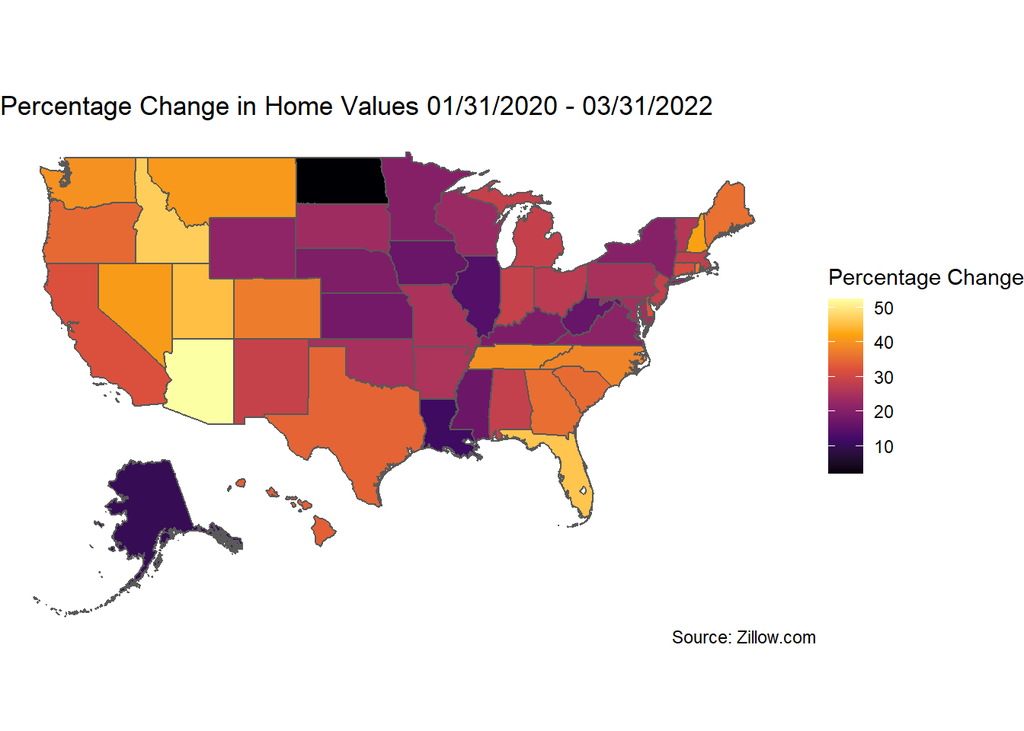

```r
pandemic_changes <- ggplot(data = housing_merged_state_pandemic,
             aes(fill = percent_change)) +
  geom_sf() +
  xlim(-125, -65) +
  ylim(20, 50) +
  labs(
    fill = 'Percentage Change',
    title = 'Percentage Change in Home Values 01/31/2020 - 03/31/2022',
    caption = 'Source: Zillow.com'
  ) +
  theme_void() +
  scale_fill_viridis_c(option = 'B')

pandemic_changes
```

## Housing Inventories

Next we will look at how housing inventories have changed over the same pandemic time period. The goal of this analysis is to visualize any changes in inventory which can potentially be used to explain at least part of the changes in prices seen above. The data we use for this analysis can be found on Zillow’s archive under the inventory section [Zillow](https://www.zillow.com/research/data/). To download the dataset chose the option of, “For-Sales Inventory (Smooth, All Homes, Monthly)”. This dataset provides the count of unique listings that were active at any time in a given month.

The following code chunks will adjust the data in the same manner explained above for the `pandemic_housing` dataset.

```r
inventory <- read_csv("data/Metro_invt_fs_uc_sfrcondo_sm_month.csv")
inventory
```

```
## # A tibble: 917 x 56
##    RegionID SizeRank RegionName   RegionType StateName `2018-01-31` `2018-02-28`
##       <dbl>    <dbl> <chr>        <chr>      <chr>            <dbl>        <dbl>
##  1   102001        0 United Stat~ Country    <NA>           1426017      1383431
##  2   394913        1 New York, NY Msa        NY               68860        68409
##  3   753899        2 Los Angeles~ Msa        CA               20024        19857
##  4   394463        3 Chicago, IL  Msa        IL               42654        40975
##  5   394514        4 Dallas-Fort~ Msa        TX               24279        23203
##  6   394974        5 Philadelphi~ Msa        PA               26468        25031
##  7   394692        6 Houston, TX  Msa        TX               33594        32737
##  8   395209        7 Washington,~ Msa        DC               22361        21077
##  9   394856        8 Miami-Fort ~ Msa        FL               60382        61978
## 10   394347        9 Atlanta, GA  Msa        GA               29702        28586
## # ... with 907 more rows, and 49 more variables: 2018-03-31 <dbl>,
## #   2018-04-30 <dbl>, 2018-05-31 <dbl>, 2018-06-30 <dbl>, 2018-07-31 <dbl>,
## #   2018-08-31 <dbl>, 2018-09-30 <dbl>, 2018-10-31 <dbl>, 2018-11-30 <dbl>,
## #   2018-12-31 <dbl>, 2019-01-31 <dbl>, 2019-02-28 <dbl>, 2019-03-31 <dbl>,
## #   2019-04-30 <dbl>, 2019-05-31 <dbl>, 2019-06-30 <dbl>, 2019-07-31 <dbl>,
## #   2019-08-31 <dbl>, 2019-09-30 <dbl>, 2019-10-31 <dbl>, 2019-11-30 <dbl>,
## #   2019-12-31 <dbl>, 2020-01-31 <dbl>, 2020-02-29 <dbl>, 2020-03-31 <dbl>, ...
```

```r
inventory_longer <- inventory %>%
  pivot_longer(
    cols = -c(RegionID, SizeRank, RegionName, RegionType, StateName),
    names_to = "Date",
    values_to = "inventory_level"
  )

inventory_longer <- inventory_longer %>%
  filter(is.na(StateName) == FALSE)

inventory_longer$Date <- lubridate::ymd(inventory_longer$Date)

inventory_longer
```

```
## # A tibble: 46,716 x 7
##    RegionID SizeRank RegionName  RegionType StateName Date       inventory_level
##       <dbl>    <dbl> <chr>       <chr>      <chr>     <date>               <dbl>
##  1   394913        1 New York, ~ Msa        NY        2018-01-31           68860
##  2   394913        1 New York, ~ Msa        NY        2018-02-28           68409
##  3   394913        1 New York, ~ Msa        NY        2018-03-31           72901
##  4   394913        1 New York, ~ Msa        NY        2018-04-30           79816
##  5   394913        1 New York, ~ Msa        NY        2018-05-31           85836
##  6   394913        1 New York, ~ Msa        NY        2018-06-30           90364
##  7   394913        1 New York, ~ Msa        NY        2018-07-31           92447
##  8   394913        1 New York, ~ Msa        NY        2018-08-31           91918
##  9   394913        1 New York, ~ Msa        NY        2018-09-30           90658
## 10   394913        1 New York, ~ Msa        NY        2018-10-31           89828
## # ... with 46,706 more rows
```

```r
inventory_jan_2020 <- inventory_longer %>%
  group_by(StateName) %>%
  filter(Date == '2020-01-31') %>%
  summarise(StateName, Date, avg_inventory = mean(inventory_level)) %>%
  unique()
inventory_march_2022 <- inventory_longer %>%
  group_by(StateName) %>%
  filter(Date == '2022-03-31') %>%
  summarise(StateName, Date, avg_inventory = mean(inventory_level)) %>%
  unique()
pandemic_inventory <- inventory_jan_2020 %>%
  inner_join(inventory_march_2022, by = 'StateName', suffix = c("_jan", "_mar"))

pandemic_inventory <- pandemic_inventory %>%
  mutate(
    percentage_change = ((avg_inventory_mar-avg_inventory_jan)/avg_inventory_jan) * 100
  )

pandemic_inventory
```

```
## # A tibble: 51 x 6
## # Groups:   StateName [51]
##    StateName Date_jan   avg_inventory_jan Date_mar   avg_inventory_mar
##    <chr>     <date>                 <dbl> <date>                 <dbl>
##  1 AK        2020-01-31              528. 2022-03-31              249.
##  2 AL        2020-01-31             1133. 2022-03-31              577.
##  3 AR        2020-01-31              708. 2022-03-31              321.
##  4 AZ        2020-01-31             3109. 2022-03-31             2041.
##  5 CA        2020-01-31             2506. 2022-03-31             1556.
##  6 CO        2020-01-31             1587. 2022-03-31              740.
##  7 CT        2020-01-31             3319. 2022-03-31             1226.
##  8 DC        2020-01-31            18247  2022-03-31            11730
##  9 DE        2020-01-31             2931  2022-03-31             1140.
## 10 FL        2020-01-31             6512. 2022-03-31             2709.
## # ... with 41 more rows, and 1 more variable: percentage_change <dbl>
```

### Inventory Plotting

In the plot below, we can see the visual representation of the data above. While two states are missing monthly averages, we can see that every state experienced a decline in home inventory levels during the pandemic. Interestingly, we can see that some of the states that experienced high percentage changes in price (such as Washington, California, and Arizona) had lower inventory changes overall compared to other states. However, we can see that the opposite is true for some states in the Northeast or Southeast.

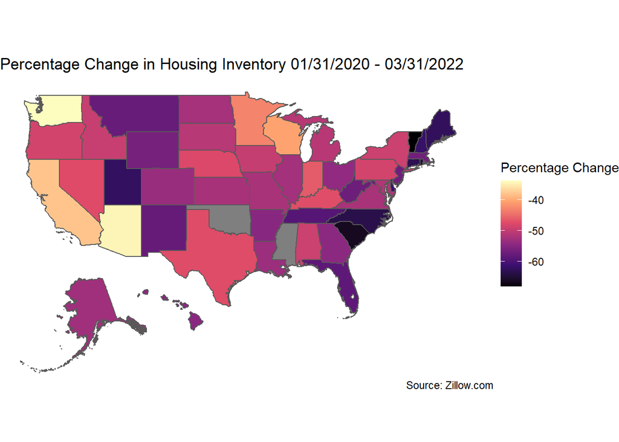

```r
inventory_merged_pandemic <- state_shapes %>%
  st_transform(4326) %>%
  inner_join(pandemic_inventory, by = c("STATE" = "StateName"))


inventory_changes_pandemic <- ggplot(data = inventory_merged_pandemic,
             aes(fill = percentage_change)) +
  geom_sf() +
  xlim(-125, -65) +
  ylim(20, 50) +
  labs(
    fill = 'Percentage Change',
    title = 'Percentage Change in Housing Inventory 01/31/2020 - 03/31/2022',
    caption = 'Source: Zillow.com'
  ) +
  theme_void() +
  scale_fill_viridis_c(option = 'A')

inventory_changes_pandemic
```

## Current Wages

Next, to progress our analysis to the final goal of understanding changes in household budgets, we scrape average wages for each state in the US, clean the data, and adjust the data to produce an average annual income for each state.

```r
paths_allowed("https://www.bls.gov/charts/county-employment-and-wages/percent-change-aww-by-state.htm/")
```

```
##
 www.bls.gov
```

```
## [1] TRUE
```

```r
wages_html <- read_html("https://www.bls.gov/charts/county-employment-and-wages/percent-change-aww-by-state.htm/")

wages <- wages_html %>%
   html_nodes("table") %>%
   html_table() %>%
  as.data.frame()


wages <- wages %>%
  rename(percent_change = Percent.change) %>%
  rename(september_2020_avg_weekly_wages_dollars = September.2020.average.weekly.wages) %>%
  rename(september_2021_avg_weekly_wages_dollars = September.2021.average.weekly.wages) %>%
  rename(net_change_dollars = Net.change)


wages$percent_change <- wages$percent_change %>%
  str_replace('%', '') %>%
  as.numeric()

wages$september_2020_avg_weekly_wages_dollars <- wages$september_2020_avg_weekly_wages_dollars %>%
  str_replace('\\$', '') %>%
  str_replace(',', '') %>%
  as.numeric()

wages$september_2021_avg_weekly_wages_dollars <- wages$september_2021_avg_weekly_wages_dollars %>%
  str_replace('\\$', '') %>%
  str_replace(',', '') %>%
  as.numeric()

wages$net_change_dollars <- wages$net_change_dollars %>%
  str_replace('\\$', '') %>%
  as.numeric()


wages <- wages %>%
  mutate(
    annual_2020_wages = (september_2020_avg_weekly_wages_dollars*52),
    annual_2021_wages = (september_2021_avg_weekly_wages_dollars*52)
  )

head(wages)
```

```
##        State percent_change september_2020_avg_weekly_wages_dollars
## 1    Alabama            5.3                                     978
## 2     Alaska            3.4                                    1165
## 3    Arizona            7.0                                    1091
## 4   Arkansas            7.8                                     893
## 5 California            7.7                                    1464
## 6   Colorado            7.0                                    1235
##   september_2021_avg_weekly_wages_dollars net_change_dollars annual_2020_wages
## 1                                    1030                 52             50856
## 2                                    1205                 40             60580
## 3                                    1167                 76             56732
## 4                                     963                 70             46436
## 5                                    1576                112             76128
## 6                                    1322                 87             64220
##   annual_2021_wages
## 1             53560
## 2             62660
## 3             60684
## 4             50076
## 5             81952
## 6             68744
```

## Mortgage Interest Rates

Next, we will look at mortgage interest rates fluctuation. Specifically, we will look at how rates have changed over the past two years during the pandemic. Following this, in the next section we will compute an average mortgage budget change from January 2020 - March 2022based on current average home value, wages, and mortgage interest rates.

The following dataset is from the Federal Reserve Bank of St. Louis and can be found here: [FRED](https://fred.stlouisfed.org/series/MORTGAGE30US).

```r
mortgage_ir <- read_csv('data/MORTGAGE30US.csv')
mortgage_ir <- mortgage_ir %>%
  rename(mortgage_ir_30year = MORTGAGE30US) %>%
  rename(date = DATE)

mortgage_ir
```

```
## # A tibble: 2,665 x 2
##    date       mortgage_ir_30year
##    <date>                  <dbl>
##  1 1971-04-02               7.33
##  2 1971-04-09               7.31
##  3 1971-04-16               7.31
##  4 1971-04-23               7.31
##  5 1971-04-30               7.29
##  6 1971-05-07               7.38
##  7 1971-05-14               7.42
##  8 1971-05-21               7.44
##  9 1971-05-28               7.46
## 10 1971-06-04               7.52
## # ... with 2,655 more rows
```

### Interest Rate Visualizations

Next, we will visualize the data from the Federal Reserve in plot #1 to gain an understanding of how mortgage rates have changed since the early 1970s to now. Additionally, in plot #2, we visualize how mortgage rates have changed recently since the beginning of the pandemic.

#### Plot 1

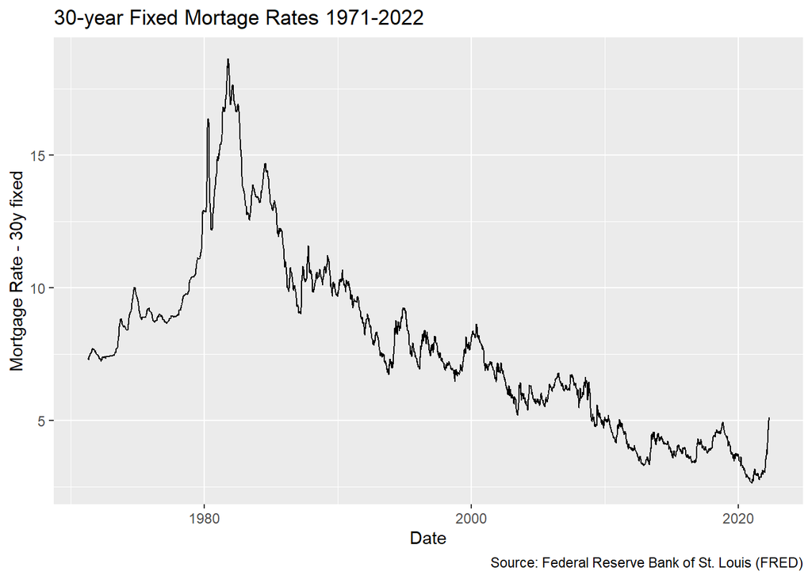

```r
mortgage_ir %>%
  ggplot() +
  aes(
    x = date,
    y = mortgage_ir_30year
  ) +
  geom_line() +
  labs(
    x = 'Date',
    y = 'Mortgage Rate - 30y fixed',
    title = '30-year Fixed Mortage Rates 1971-2022',
    caption = 'Source: Federal Reserve Bank of St. Louis (FRED)'
  )
```

#### Plot 2

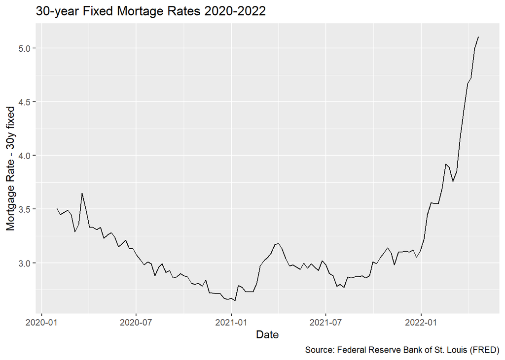

```r
mortgage_ir %>%
  filter(
    date >= '2020-01-30'
  ) %>%
  ggplot() +
  aes(
    x = date,
    y = mortgage_ir_30year
  ) +
  geom_line() +
  labs(
    x = 'Date',
    y = 'Mortgage Rate - 30y fixed',
    title = '30-year Fixed Mortage Rates 2020-2022',
    caption = 'Source: Federal Reserve Bank of St. Louis (FRED)'
  )
```

We can see above in plot 1 that while mortgage rates have spiked recently as the FED has raised interest rates to counteract inflation, compared to historical rates since the early 1970s, the current interest rate environment is certainly not extreme. However, it is important to understand that data is highly contextualized. Because of this, we know that although current rates are objectively low compared to historical rates, nonetheless, people are accustomed to lower rates. This acclimation to a lower interest rate environment likely influences buying behaviors. Therefore, to gain an accurate understanding of how current consumers feel about the change, it is more helpful to narrow our window to the past couple years. In the next section, we will compute the expected mortgage budget change in dollar terms. This will allow us to perceive a more accurate depiction of the current situation that places more importance on current factors such as budgeting and purchasing behaviors.

## Current Mortgage Budget Analysis

To perform the following budget analysis, we will take the `pandemic_housing`, `wages`, and `mortgage_ir` datasets and use the wrangled data to compute expected changes in mortgage payments for each state based on housing prices, annual wages, and mortgage interest rates. For simplicity, we assume that the “average” buyer as indicated by the average price will put up 20% to avoid paying mortgage insurance. We also assume that the remaining 80% of the home value will be covered by a mortgage loan. Because of these assumptions, we can reasonably state that our conclusions will reflect best case scenarios. To take this analysis further, we can later incorporate average down payment percentages and mortgage insurance rates to derive an even more accurate budget analysis.

To start, we will make some minor adjustments to the three datasets. Following these adjustments, we will create the final dataset.

```r
pandemic_housing <- pandemic_housing %>%
  mutate(
    avg_mortgage_jan = (avg_value_jan*0.8),
    avg_mortgage_mar = (avg_value_mar*0.8)
  )


mortgage_ir_pandemic <- mortgage_ir %>%
  filter(date >= '2020-01-30'&
         date <= '2022-03-31')


mortgage_ir_pandemic <- mortgage_ir_pandemic %>%
  add_row(date = lubridate::ymd('2020-01-31'), mortgage_ir_30year = 3.51) %>%
  arrange(date)


# pandemic_housing
# wages
# mortgage_ir_pandemic
```

Next, we take the final versions of our three datasets and join them to create the final dataset upon which we will perform the mortgage budget analysis.

```r
pandemic_housing_final <- pandemic_housing %>%
  left_join(mortgage_ir_pandemic, by = c("Date_jan" = "date")) %>%
  left_join(mortgage_ir_pandemic, by = c("Date_mar" = "date"))


pandemic_housing_final <- pandemic_housing_final %>%
  rename(jan_rate = mortgage_ir_30year.x) %>%
  rename(mar_rate = mortgage_ir_30year.y)


pandemic_housing_final <- pandemic_housing_final %>%
  mutate(
    state_name = state.name[match(State, state.abb)]
  ) %>%
  filter(State != "DC")


pandemic_housing_final <- pandemic_housing_final %>%
  inner_join(wages, by = c("state_name" = "State"), suffix = c("_price", "_wage"))


pandemic_housing_final <- pandemic_housing_final %>%
  mutate(
    monthly_payment_jan = pmt((jan_rate/100)/12, 30*12, avg_mortgage_jan, 0),
    monthly_payment_mar = pmt((mar_rate/100)/12, 30*12, avg_mortgage_mar, 0),
    payment_difference = monthly_payment_jan - monthly_payment_mar,
    mortgage_proportion_wages_jan = ((abs(monthly_payment_jan)*12)/annual_2020_wages)*100,
    mortgage_proportion_wages_mar = ((abs(monthly_payment_mar)*12)/annual_2021_wages)*100,
    budget_change_as_proportion_of_wages = mortgage_proportion_wages_mar - mortgage_proportion_wages_jan
  )



pandemic_housing_final
```

```
## # A tibble: 50 x 23
## # Groups:   State [50]
##    State Date_jan   avg_value_jan Date_mar   avg_value_mar percent_change_price
##    <chr> <date>             <dbl> <date>             <dbl>                <dbl>
##  1 AK    2020-01-31       268123. 2022-03-31       295374.                 10.2
##  2 AL    2020-01-31       133447. 2022-03-31       171796.                 28.7
##  3 AR    2020-01-31       103288. 2022-03-31       129796.                 25.7
##  4 AZ    2020-01-31       266826. 2022-03-31       407196.                 52.6
##  5 CA    2020-01-31       664717. 2022-03-31       877880.                 32.1
##  6 CO    2020-01-31       374253. 2022-03-31       514611.                 37.5
##  7 CT    2020-01-31       318743. 2022-03-31       418428.                 31.3
##  8 DE    2020-01-31       273582. 2022-03-31       362498.                 32.5
##  9 FL    2020-01-31       262442. 2022-03-31       383522.                 46.1
## 10 GA    2020-01-31       176306. 2022-03-31       239172.                 35.7
## # ... with 40 more rows, and 17 more variables: avg_mortgage_jan <dbl>,
## #   avg_mortgage_mar <dbl>, jan_rate <dbl>, mar_rate <dbl>, state_name <chr>,
## #   percent_change_wage <dbl>, september_2020_avg_weekly_wages_dollars <dbl>,
## #   september_2021_avg_weekly_wages_dollars <dbl>, net_change_dollars <dbl>,
## #   annual_2020_wages <dbl>, annual_2021_wages <dbl>,
## #   monthly_payment_jan <dbl>, monthly_payment_mar <dbl>,
## #   payment_difference <dbl>, mortgage_proportion_wages_jan <dbl>, ...
```

### Visualization of Mortgage Payment Changes

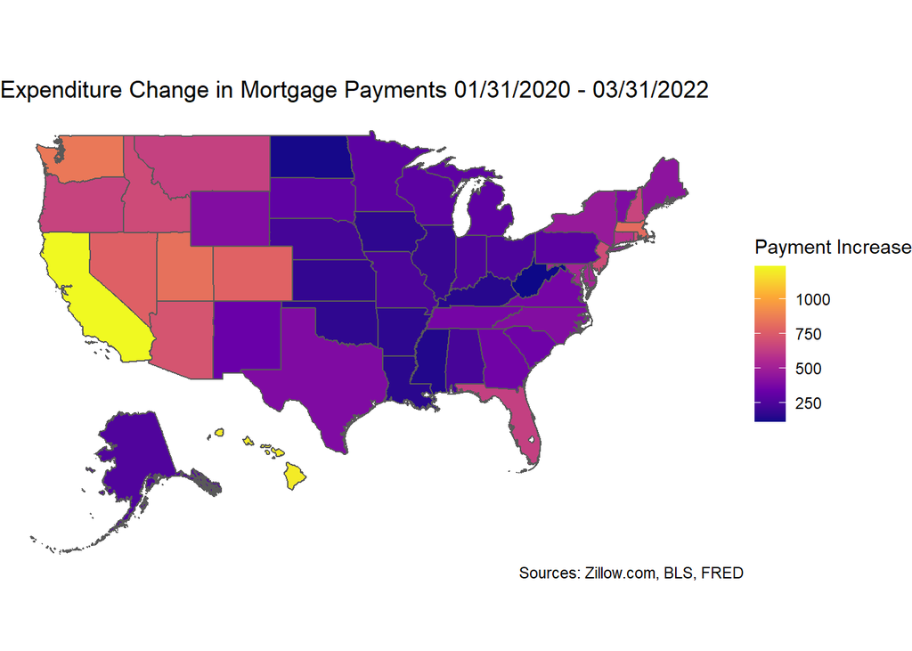

```r
pandemic_housing_final_shape <- state_shapes %>%
  st_transform(4326) %>%
  inner_join(pandemic_housing_final, by = c("STATE" = "State"))


budget_changes <- ggplot(data = pandemic_housing_final_shape,
             aes(fill = payment_difference)) +
  geom_sf() +
  xlim(-125, -65) +
  ylim(20, 50) +
  labs(
    fill = 'Payment Increase',
    title = 'Expenditure Change in Mortgage Payments 01/31/2020 - 03/31/2022',
    caption = 'Sources: Zillow.com, BLS, FRED'
  ) +
  theme_void() +
  scale_fill_viridis_c(option = 'C')

budget_changes
```

```r
mortgage_prop_wage <- pandemic_housing_final %>%
  select(state_name, mortgage_proportion_wages_jan, mortgage_proportion_wages_mar, budget_change_as_proportion_of_wages) %>%
  arrange(desc(budget_change_as_proportion_of_wages))
mortgage_prop_wage
```

```
## # A tibble: 50 x 5
## # Groups:   State [50]
##    State state_name   mortgage_proportio~ mortgage_proporti~ budget_change_as_p~
##    <chr> <chr>                      <dbl>              <dbl>               <dbl>
##  1 HI    Hawaii                      46.0               68.6                22.6
##  2 UT    Utah                        28.1               43.9                15.8
##  3 CA    California                  37.7               53.1                15.5
##  4 ID    Idaho                       26.0               40.7                14.7
##  5 MT    Montana                     26.6               40.5                13.9
##  6 NV    Nevada                      27.3               41.0                13.6
##  7 RI    Rhode Island                25.6               38.8                13.2
##  8 AZ    Arizona                     20.3               33.3                13.0
##  9 CO    Colorado                    25.2               37.1                12.0
## 10 FL    Florida                     21.1               32.7                11.5
## # ... with 40 more rows
```

In regards to mortgage budgeting, we can see that the average wage and mortgage in each state experienced an increase in the proportion of wages needed to cover mortgage payments. However, we can see that some states experienced proportional changes in excess of 10% while many others only saw a less than 5% increase. Essentially, what we can distill from this data is that new home owners with a mortgage in the United States have to budget more of their wages to cover their mortgage payments. As we found earlier, this change is due to rising home prices and interest rates for which wages have not kept pace with. Some conclusions we might draw from this analysis might be that home owners should wait to purchase a home until they are more financially secure or interest rates fall. Additionally, when considering where to live, one might want to consider the cost of living as evident by the required mortgage budget as a percentage of wages.